# Module 3 Report

480133780, 480378222, 480379414, 480398611

10/11/2019

# Abstract

This module report analyses the aggregation of several datasets using ANOVA and evaluates the effectiveness of the kiwifruit extract treatment on the tenderness in red meat in conjunction with other factors, namely the muscle the sample is taken from, the ageing period and the cooking method. An ANOVA model was established to investigate the interactions between these factors. Interaction plots were made to further explore the significance of the interactions. Contrast plots were generated to assess the significance and meaningfulness of the differences between the means of tenderness scores of the meat samples with different combinations of treatment. These results suggests that the kiwifruit extract improves the tenderness in red meat, and consumers are highly likely to tell the differences between the meat, and such that they are able to eat more tender meat.

# Introduction

The aim of this report is to answer the question of whether kiwifruit extract treatment improves tenderness. This is the starting point of the investigation, then we move to assess if there is an interaction between treatment and other variables of interest, namely the muscle the sample is taken from, the ageing period and the cooking method. The next question is whether there are differences between cooking methods, between aging periods and between muscles. If so, then we ask whether sizes of the differences are significant. After answering all of these questions, we then explore if this makes a difference to the consumers.

```r
library(ggplot2)
library(tidyverse)
library(readxl)
library(plyr)
library(ggpubr)
library(cowplot)
library(reshape)
library(ggfortify)
library(emmeans)
library(tidyverse)
library(dplyr)
library(tibble)
library(emmeans)
library(ggfortify)
library(knitr)
library(kableExtra)
library(car)
library(broom)
```

# DATA2902: Aggregation of datasets - Creating *Tenderness* column

This code reads all the raw consumer level data into dataframes using *map*.

```r
data = read_excel("infusions_data_2902.xlsx")
myfiles <- list.files(path = "raw_consumer", pattern = ".xls")
myfiles <- paste("./raw_consumer/",myfiles, sep ="")
mydata <-  myfiles %>% map(.,read_xls, na="NA")
# call in a second time because of different notation by collaborators
filename = "Final_infusion.csv"

mdata = read.csv(filename, header = T, na = c("NA",""," ")) %>%
  janitor::clean_names()

mdata = mdata[mdata$cut != "TDR062",]
# glimpse(mdata)
```

After reading the data, we create our own function to aggregate the mean data for each product type. Again with the map function and our own function, a list of aggregate means are created. In the end we merge all the tables together and join that with the original table.

```r
func <- function(x){
  data_group <- x %>% group_by(prod) %>% dplyr::summarise(., mean = round(mean(tender,na.rm = TRUE)))
  colnames(data_group) <- c("EQSRef", "Tender")
  data_group
}

my_list = map(mydata, func)

merged_group = merge_all(my_list)


data <- left_join(data, merged_group, by="EQSRef")

write.csv(data, file = "Final_infusion.csv")
```

```r
data = read_csv("Final_infusion.csv", na ="NA")
data = data[data$CUT !="TDR062", ]
data = data %>% janitor::clean_names()
```

```r
kiwiq = data %>% filter(!is.na(trial_notes), !is.na(tender), !is.na(cut), !is.na(d_aged), !is.na(cook), !is.na(eqs_ref), !is.na(carcase_no), !is.na(key_1))
```

```r
treat = kiwiq$trial_notes
tender = kiwiq$tender
cut = kiwiq$cut
kiwiq$d_aged = factor(kiwiq$d_aged)
d_aged = kiwiq$d_aged
cook = kiwiq$cook
eqs = kiwiq$eqs_ref
carcase = kiwiq$carcase_no
key1 = kiwiq$key_1

trt_ten = data.frame(treat, tender, cut, d_aged, cook, eqs, carcase, key1)
ctrl = trt_ten %>%
  filter(treat == "Control")
trt = trt_ten %>%
  filter(treat!="Control")
# trt_ten
```

# The ANOVA Model

## 4.1 Setting up the ANOVA model - *Backward variable selection*

Just before we jump to the analysis of the differences between the tenderness scores, we need to set up an ANOVA model with the significant combinations as we are only interested in those pairs. The *backward variable selection* method is adopted and is set out as follows.

## 4.2 *Step 1: Generating our first model*

We start with our first model of a big two-way multi-factor ANOVA which has all factors in it and the block as well. We have three unique identifiers in our dataset: EQSRef, Carcase No. and KEY 1. They are categorical variables that are of no scientific interest, but they might help us explain some variations in our data. The *EQSRef* (the unique sample identifier) is of no interest here as it is merely the numbering of the samples which would not make the estimate of the error variance more precise. *carcase* is the same as *key1*, so we only need either one of them. We will be using *carcase* as the blocking variable in our model.

In order to adjust for the remaining two blocks, a two-way ANOVA test is ideal to be used.

```r
mf = aov(tender ~ carcase + trial_notes*cut + trial_notes*d_aged + trial_notes*cook + cut*d_aged + cut*cook + d_aged*cook, data = kiwiq)
car::Anova(mf, type = "II")
```

```
## Anova Table (Type II tests)
##
## Response: tender
##                    Sum Sq  Df  F value    Pr(>F)
## carcase               534   1   3.7006  0.054728 .
## trial_notes         43903   1 304.0615 < 2.2e-16 ***
## cut                 83469   1 578.0871 < 2.2e-16 ***
## d_aged                477   1   3.3067  0.069351 .
## cook                 4795   3  11.0702 3.915e-07 ***
## trial_notes:cut      1104   1   7.6436  0.005821 **
## trial_notes:d_aged    434   1   3.0055  0.083346 .
## trial_notes:cook     1243   3   2.8695  0.035583 *
## cut:d_aged             12   1   0.0818  0.775005
## cut:cook             7448   3  17.1948 7.567e-11 ***
## d_aged:cook           217   3   0.5020  0.680962
## Residuals          122874 851
## ---
## Signif. codes:  0 '***' 0.001 '**' 0.01 '*' 0.05 '.' 0.1 ' ' 1
```

It is evident in the ANOVA table that the insignificant pairs are as follows, *treatment and ageing period*, *muscle and ageing period* and *ageing period and cooking method*.

## 4.3 *Step 2: Removing insignificant combinations*

We retain all of the significant pairs by removing the ones with p-values greater than 0.05, one at a time starting with the least significant ie *cut and ageing period*.

```r
ms = aov(tender ~ carcase + trial_notes*cut + trial_notes*d_aged + trial_notes*cook + cut+d_aged + cut*cook + d_aged*cook, data = kiwiq)
car::Anova(ms, type = "II")
```

```
## Anova Table (Type II tests)
##
## Response: tender
##                    Sum Sq  Df  F value    Pr(>F)
## carcase               535   1   3.7077   0.05450 .
## trial_notes         43913   1 304.4592 < 2.2e-16 ***
## cut                 83469   1 578.7108 < 2.2e-16 ***
## d_aged                477   1   3.3102   0.06920 .
## cook                 4795   3  11.0821 3.849e-07 ***
## trial_notes:cut      1092   1   7.5703   0.00606 **
## trial_notes:d_aged    433   1   3.0055   0.08334 .
## trial_notes:cook     1247   3   2.8820   0.03499 *
## cut:cook             7450   3  17.2176 7.325e-11 ***
## d_aged:cook           217   3   0.5015   0.68136
## Residuals          122886 852
## ---
## Signif. codes:  0 '***' 0.001 '**' 0.01 '*' 0.05 '.' 0.1 ' ' 1
```

Then we move on to remove *ageing period and cook*.

```r
ms = aov(tender ~ carcase + trial_notes*cut + trial_notes*d_aged + trial_notes*cook + cut+d_aged + cut*cook + d_aged+cook, data = kiwiq)
car::Anova(ms, type = "II")
```

```
## Anova Table (Type II tests)
##
## Response: tender
##                    Sum Sq  Df  F value    Pr(>F)
## carcase               541   1   3.7602  0.052816 .
## trial_notes         44806   1 311.1956 < 2.2e-16 ***
## cut                 83445   1 579.5599 < 2.2e-16 ***
## d_aged                477   1   3.3160  0.068957 .
## cook                 4795   3  11.1015 3.742e-07 ***
## trial_notes:cut      1079   1   7.4950  0.006316 **
## trial_notes:d_aged    495   1   3.4399  0.063984 .
## trial_notes:cook     1269   3   2.9380  0.032453 *
## cut:cook             7434   3  17.2113 7.372e-11 ***
## Residuals          123103 855
## ---
## Signif. codes:  0 '***' 0.001 '**' 0.01 '*' 0.05 '.' 0.1 ' ' 1
```

Now we are ready to analyse the significant differences.

# 1. Primary Question: Kiwi and Tenderness

## 1.1 Is there an interaction between kiwi extract and other factors? *(Kiwifruit Extract Treatment and Cooking Methods)*

There are some factors which are of interest: the muscle that the sample is from (“cut”), the aging period of the sample (“d_aged”) and how the muscle is cooked (“cook”).

### 1.2 Interaction plot:

In an interaction plot we can assess the potentially different effects that the levels of different independent variables have on one another. Similar or equal gradients across all levels indicates little or no interaction effect, while largely different gradients may indicate a significant interaction which should be accounted for in our ANOVA model.

### 1.2.1 Kiwi Extract:Cooking Method

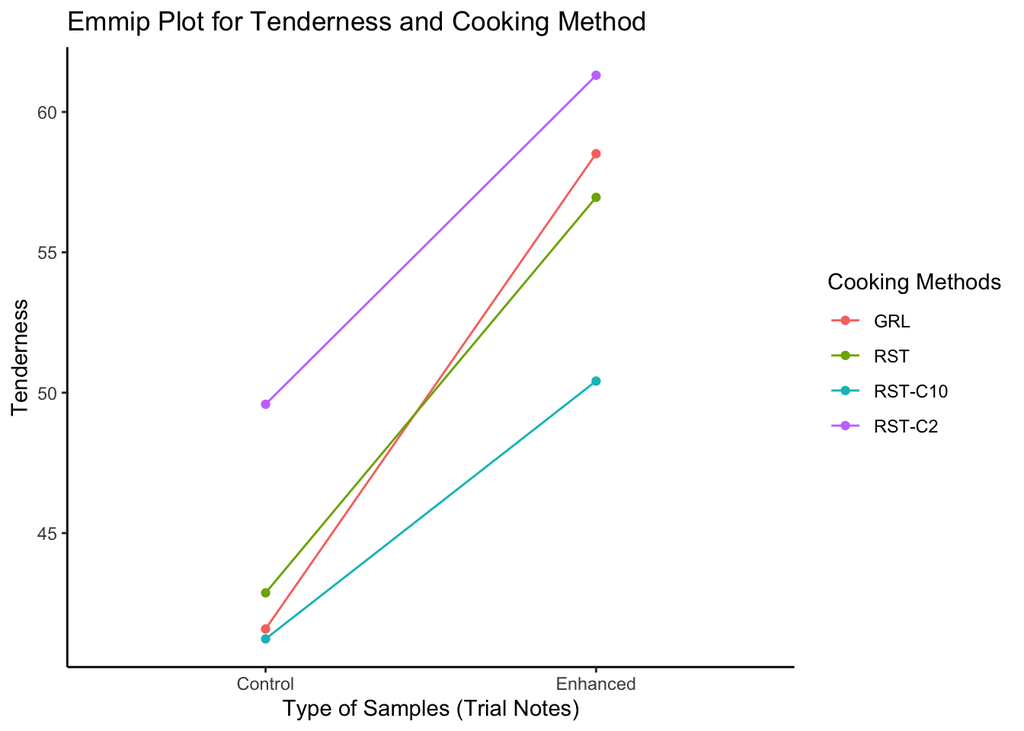

```r
e_cook = emmeans(ms, ~ trial_notes + cook)
# e_cook
emmip(e_cook, cook ~ trial_notes) + theme_classic()+labs(col ="Cooking Methods")+ xlab("Type of Samples (Trial Notes)")+ ylab("Tenderness")+ggtitle("Emmip Plot for Tenderness and Cooking Method")
```

The interaction plot between trial notes and cooking method indicates differences in the effect meat enhancement and cooking type. RST-C2 and RST-C10have similar positive gradient. RST and GRL have larger positive gradients than the afforementioned cooking methods. GRL even crosses the RST line. This indicates a potentially significant interaction between enhancement and the various ways the meat was cooking

### 1.2.2 Kiwi Extract:Cut

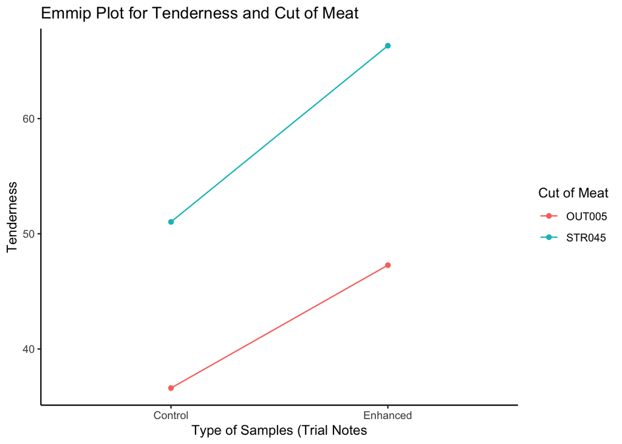

```r
e_cut = emmeans(ms, ~ trial_notes + cut)
# e_cut
emmip(e_cut, cut ~ trial_notes) + theme_classic()+labs(col = "Cut of Meat")+ xlab("Type of Samples (Trial Notes")+ylab("Tenderness")+ggtitle("Emmip Plot for Tenderness and Cut of Meat")
```

The interaction plot of trial notes and cut indicates a difference in tenderness for the two different cuts of meat. In terms of interaction, the two lines do not appear to be parallel, with STR045 (striploin) having a greater gradient than OUT005 (outer flat). This indicates an interaction between trial notes and cut. It can’t be determined from the plot if this interaction is significant, however, we can determine this based on the anova model output.

### 1.2.3 Kiwi Extract:Aging Period

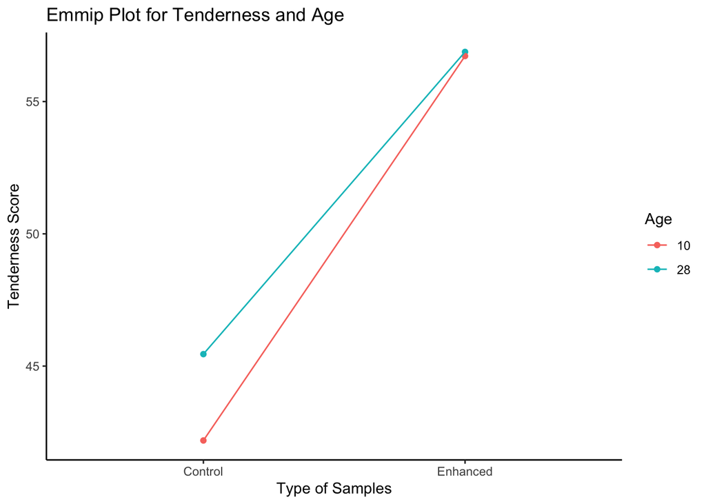

```r
e_age = emmeans(ms, ~ trial_notes + d_aged)
# e_cut
emmip(e_age, d_aged ~ trial_notes) + theme_classic()+labs(col = "Age")+ xlab("Type of Samples")+ylab("Tenderness Score")+ggtitle("Emmip Plot for Tenderness and Age")
```

The interaction plot of trial notes and days aged shows that the two aging periods almost converge. Meat aged for ten days has a greater gradient. This indicates an interaction between these two factors. Further, it indicates that the enhancement of the meat provides a greater proportional increase in meat aged for 10 days than it does in meat aged for 28 days.

We can also use a formal test to assess if each of these interactions are significant.

```r
unique(mdata$cook)
```

```
## [1] GRL     RST     RST-C10 RST-C2
## Levels: GRL RST RST-C10 RST-C2
```

```r
car::Anova(ms, type = "II")
```

```
## Anova Table (Type II tests)
##
## Response: tender
##                    Sum Sq  Df  F value    Pr(>F)
## carcase               541   1   3.7602  0.052816 .
## trial_notes         44806   1 311.1956 < 2.2e-16 ***
## cut                 83445   1 579.5599 < 2.2e-16 ***
## d_aged                477   1   3.3160  0.068957 .
## cook                 4795   3  11.1015 3.742e-07 ***
## trial_notes:cut      1079   1   7.4950  0.006316 **
## trial_notes:d_aged    495   1   3.4399  0.063984 .
## trial_notes:cook     1269   3   2.9380  0.032453 *
## cut:cook             7434   3  17.2113 7.372e-11 ***
## Residuals          123103 855
## ---
## Signif. codes:  0 '***' 0.001 '**' 0.01 '*' 0.05 '.' 0.1 ' ' 1
```

We will perform this test for the interaction effect between kiwi extract and cooking method.

### 1.3 Is the kiwi extract:cooking method interaction significant?

**Hypothesis**

$H_{0}$: $(\alpha\gamma)_{ij}$ = 0 for i = 1,2 and j = 1,2,3,4

$H_{1}$: At least one $(\alpha\gamma)_{ij} \neq 0$

**Assumptions**

check normality and equal variance w autoplot

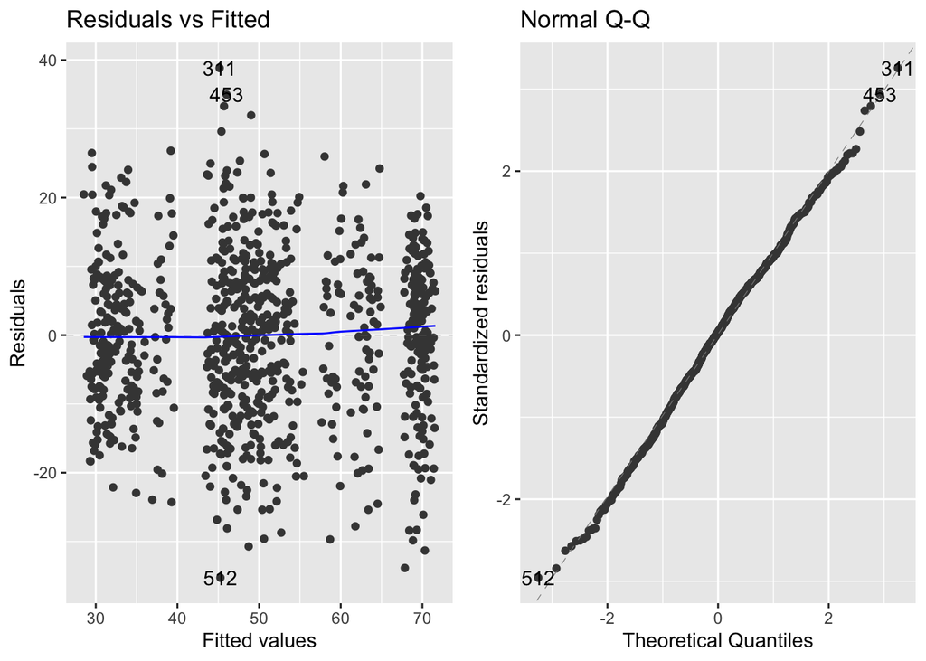

```r
autoplot(ms, which = c(1,2))
```

Our previous question addressed the assumption of the ANOVA test. We know that the assumptions of this test are satisfied.

**Test statistic**

**Observed test statistic**

$t_{0} =$ 2.9380

**p-value**

The p-value is < 0.05 which indicates that the interaction effect is significant. Thus we reject the $H_0$.

**Conclusion**

We can conclude that at least one level of the kiwi treatment factor has a significant interaction with one of the levels of cooking method.

# Question 2: Tenderness and other factors

Note: we used our finalised model that includes individual factors and interactions. In these tests, we used the individual factors.

## 2.1 Which *cooking method* is the best for tenderness?

**Hypothesis**

$H_{0}$: $\mu_{GRL} = \mu_{RST-C10} = \mu_{RST-C2} = \mu_{RST}$

$H_{1}$:At least one of the $\mu_{i} \neq \mu_{j}$

**Assumptions**

Observations are independent, have large enough sample size to rely on CLT and have equal variance.Each of the population is normal distributed.

**Test statistic**

$T = \frac{MeanSqInteraction}{MeanSResudial}$ under$H_0$ $T$ ~ $F_{3, 871-4}$

**Observed test statistic**

$t_{0}$ = 11.0702

**p-value**

$P(T \geq t_0)$ = 3.915e-07

First, we plot the values to see if they follow normal distribution and have equal variance.

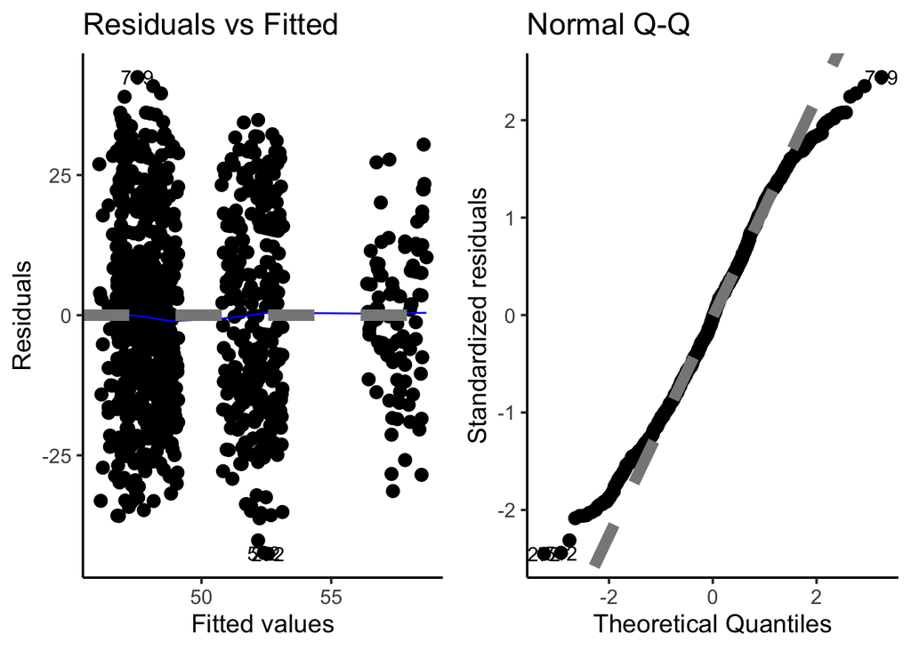

```r
fit1 = aov(tender ~ carcase + cook, data = kiwiq)
a = autoplot(fit1, which = 1:2, size = 3, ad.size = 3, colour = "black")+theme_classic(base_size = 14)
b = ggplot(data, aes(x = cook, y = tender))+geom_boxplot()+ggtitle("Tenderness for each Cooking Methods")+ylab("Tenderness")+xlab("Cooking Methods")+scale_x_discrete(labels= c("GRL" ="Grill", "RST"= "Roast", "RST-C10"="Roast cold 10mm", "RST-C2"="Roast cold 2mm"))
a
```

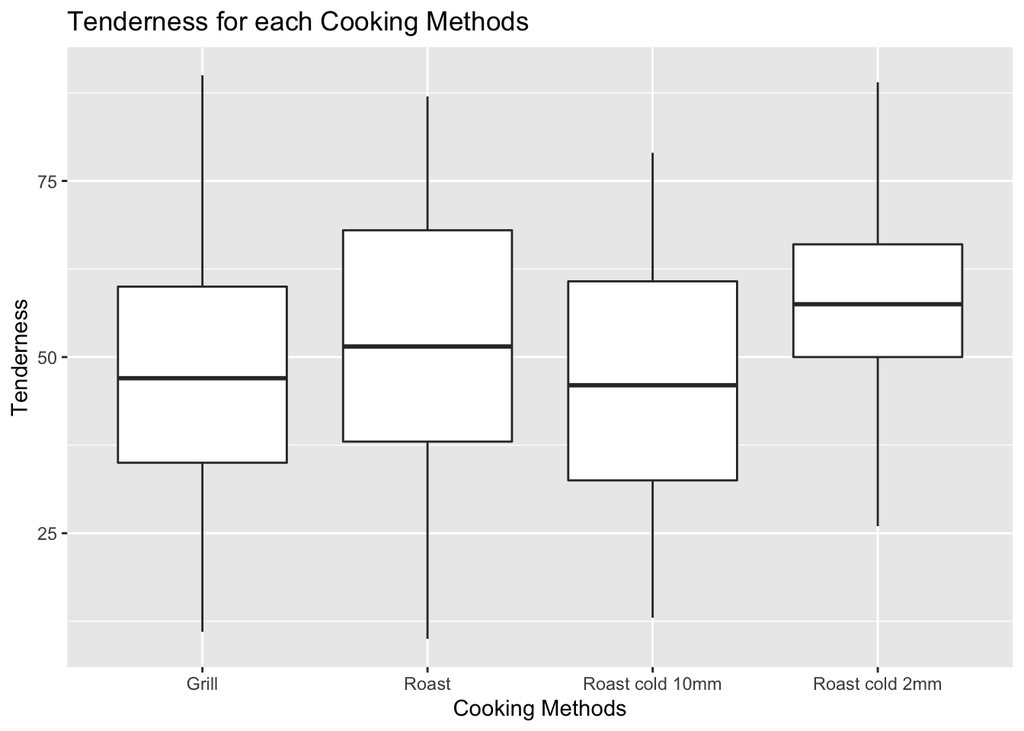

```r
b
```

They look good enough to work with, and we can also rely on the Central Limit Theorem. Interestingly enough we can see that groups are formed. It could suggest that certain cooking methods contribute to tenderness itself.

```r
fit1_em = emmeans(ms, ~cook)
```

```
## NOTE: Results may be misleading due to involvement in interactions
```

```r
contrast(fit1_em, method = "pairwise", adjust ="scheffe")
```

```
##  contrast         estimate    SE  df t.ratio p.value
##  GRL - RST           0.134 0.982 855  0.136  0.9993
##  GRL - RST-C10       4.226 1.494 855  2.828  0.0467
##  GRL - RST-C2       -5.398 1.494 855 -3.613  0.0047
##  RST - RST-C10       4.092 1.567 855  2.611  0.0788
##  RST - RST-C2       -5.532 1.567 855 -3.530  0.0062
##  RST-C10 - RST-C2   -9.624 1.932 855 -4.981  <.0001
##
## Results are averaged over the levels of: trial_notes, cut, d_aged
## P value adjustment: scheffe method with dimensionality 3
```

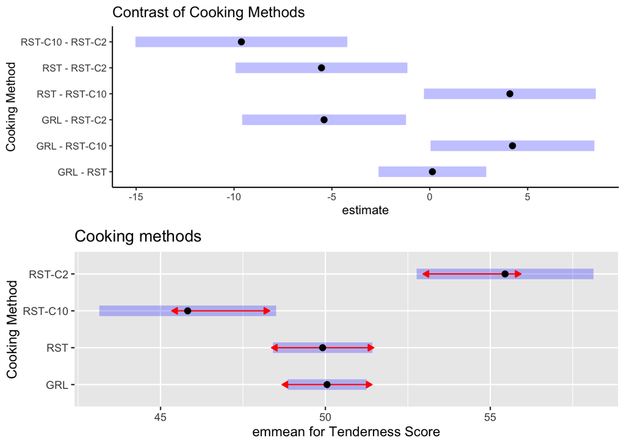

```r
a = contrast(fit1_em, adjust = "scheffe", method = "pairwise") %>% plot(colour = "black")+theme_classic(base_size = 10)+ggtitle("Contrast of Cooking Methods")+ylab("Cooking Method")

b = plot(fit1_em, comparisons = TRUE)+ylab("Cooking Method")+ggtitle("Cooking methods")+xlab("emmean for Tenderness Score")
ggarrange(a,b, nrow = 2)
```

Therefore, our plot and the p-value from our model (3.915e-07) reject the assumption that cooking method does not affect tenderness.

## 2.2 Which *part of the meat* is the best for tenderness?

**Hypothesis**

$H_{0}$: $\mu_{OUT005} = \mu_{STR045}$

$H_{1}$:$\mu_{OUT005} \neq \mu_{STR045}$

**Assumptions**

Observations are independent, have large enough sample size to rely on CLT and have equal variance.Each of the population is normal distributed.

**Test statistic**

$T = \frac{MeanSqInteraction}{MeanSResudial}$ under$H_0$ $T$ ~ $F_{1, 871-2}$

**Observed test statistic**

$t_{0}$ = 578.0871

**p-value**

$P(T \geq t_0)$ $<$ 2e-16

Since we excluded tenderloin, there are two types of cut of meats left. From these plots, we can fairly say the values follow a normal distribution and the groups have equal variance. However their values are seemingly different.

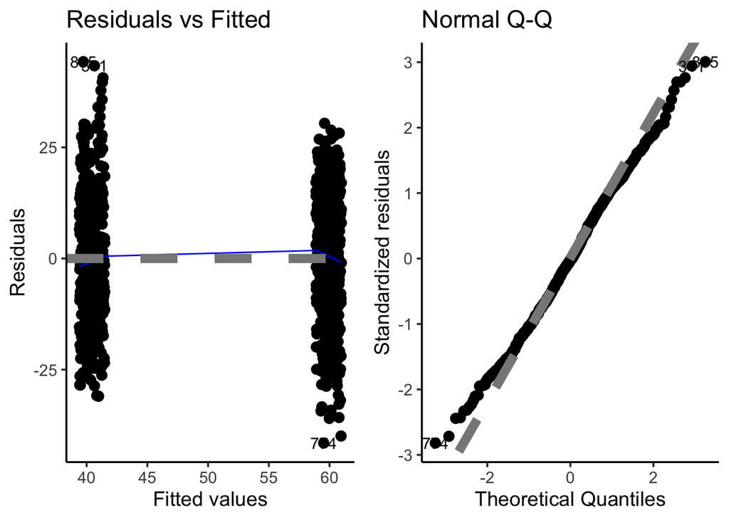

```r
fit2 = aov(tender ~ carcase + cut, data = kiwiq)
autoplot(fit2, which = 1:2, size = 3, ad.size = 3, colour = "black")+theme_classic(base_size = 14)
```

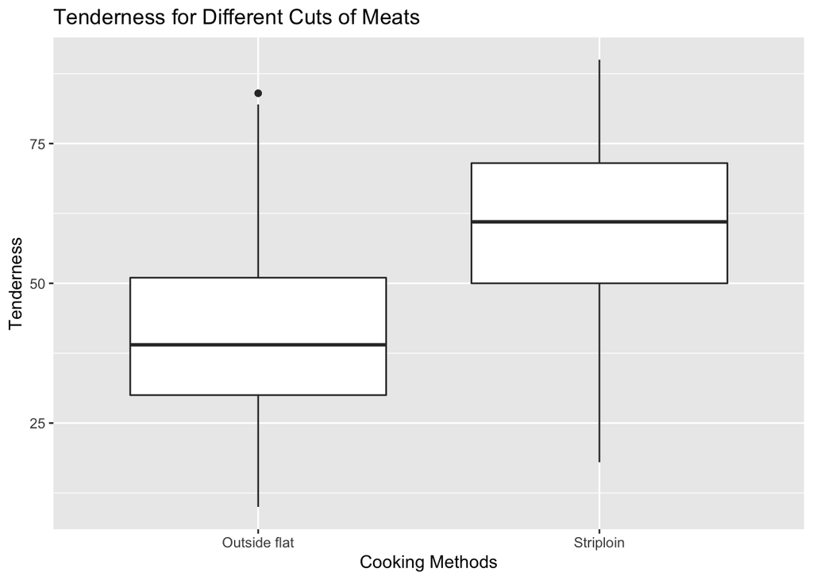

```r
ggplot(kiwiq, aes(x = cut, y = tender))+geom_boxplot()+ggtitle("Tenderness for Different Cuts of Meats")+ylab("Tenderness")+xlab("Cooking Methods")+scale_x_discrete(labels= c("OUT005" = "Outside flat", "STR045"= "Striploin"))
```

Since we are working with two groups only, we will not have a pairwise contrast plot. Even without it, this plots tells that striploin (STR045) has a higher tenderness score than outside flat meats (OUT005). Overall, the p-value (< 2.2e-16) and our plot reject the null hypothesis and having different cut of meat matters.

```r
fit2_em = emmeans(ms, ~cut)
```

```
## NOTE: Results may be misleading due to involvement in interactions
```

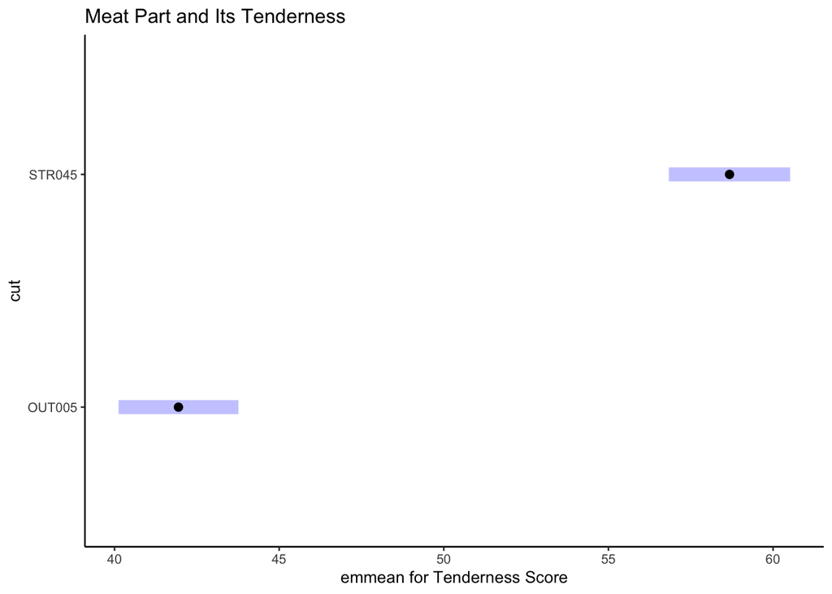

```r
confint(fit2_em, adjust = "scheffe") %>% plot(colour = "black")+theme_classic(base_size = 10)+ggtitle("Meat Part and Its Tenderness")+xlab("emmean for Tenderness Score")
```

## 2.3 Does *ageing period* matter?

**Hypothesis**

$H_{0}$: $\mu_{10} = \mu_{28}$

$H_{1}$: $\mu_{10} \neq \mu_{28}$

**Assumptions**

Observations are independent, have large enough sample size to rely on CLT and have equal variance.Each of the population is normal distributed.

**Test statistic**

$T = \frac{MeanSqInteraction}{MeanSResudial}$ under$H_0$ $T$ ~ $F_{1, 871-2}$

**Observed test statistic**

$t_{0}$ = 3.3067

**p-value**

$P(T \geq t_0)$ $=$ 0.069351

Even though, the data is not normal, we will proceed with the comparison. We will work with the fact that there are enough data point to rely on the CLT.

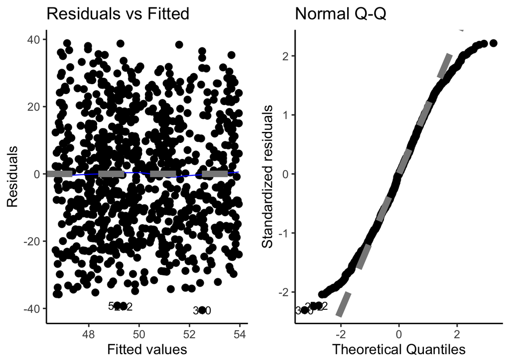

```r
fit3 = aov(tender ~ d_aged+carcase,data =kiwiq)
autoplot(fit3, which = 1:2, size = 3, ad.size = 3, colour = "black")+theme_classic(base_size = 14)
```

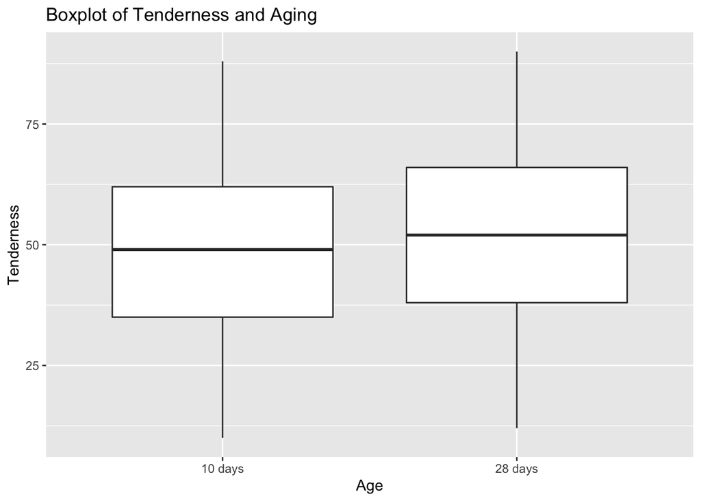

```r
ggplot(kiwiq, aes(x = d_aged, y = tender))+geom_boxplot()+ggtitle("Boxplot of Tenderness and Aging")+ylab("Tenderness")+xlab("Age")+scale_x_discrete(labels= c("10" = "10 days", "28"= "28 days"))
```

Since there are only two categories for aging, we will not do a pairwise comparison.

```r
fit3_em = emmeans(ms, ~ d_aged)
```

```
## NOTE: Results may be misleading due to involvement in interactions
```

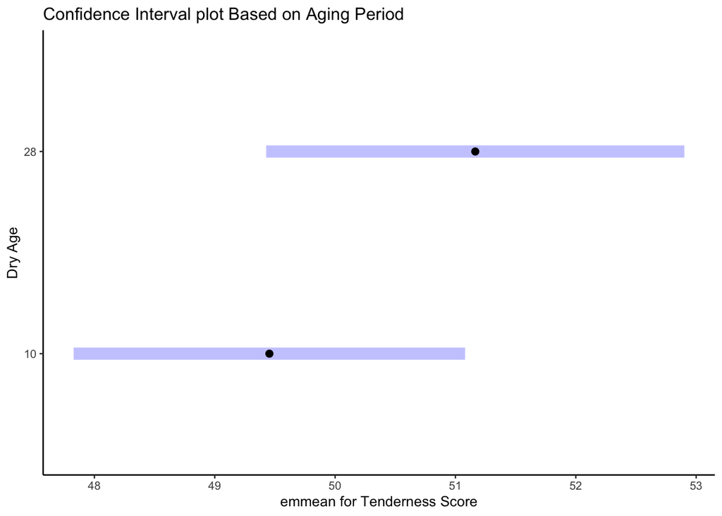

```r
confint(fit3_em, adjust = "scheffe") %>% plot(colour = "black")+theme_classic(base_size = 10)+ggtitle("Confidence Interval plot Based on Aging Period")+ylab("Dry Age")+xlab("emmean for Tenderness Score")
```

Even though, there is a difference between the aging for 10 days and aging for 28 days, it would be difficult to recognise which meat is older based on just tasting. The values are quite close to the mean value, and their tenderness is quite similar.

Even the p-value from our model (0.069351) suggested that their mean value is the same, by keeping the null hypothesis.

# Question 3: Post hoc comparisons - *Significant Differences*

In isolation, there are significant interaction effects between kiwifruit extract treatment and the cooking method and cut. However, if we combine them in the same model, how many are still significant? We would like to learn more about what is leading to the significance.

In this multi-factor scenario, the comparisons we are interested in depends on whether there is a significant interaction or not. If there is no significant interaction, the levels of first factor are compared independently to the levels of the second one. If there is a significant interaction, we would like to know if one factor has a strong effect of the other factor within some or all of its levels.

The post hoc comparisons will allow us to indentify which combinations of the variables result in the the most difference for consumers.

```r
car::Anova(ms, type = "II")
```

```
## Anova Table (Type II tests)
##
## Response: tender
##                    Sum Sq  Df  F value    Pr(>F)
## carcase               541   1   3.7602  0.052816 .
## trial_notes         44806   1 311.1956 < 2.2e-16 ***
## cut                 83445   1 579.5599 < 2.2e-16 ***
## d_aged                477   1   3.3160  0.068957 .
## cook                 4795   3  11.1015 3.742e-07 ***
## trial_notes:cut      1079   1   7.4950  0.006316 **
## trial_notes:d_aged    495   1   3.4399  0.063984 .
## trial_notes:cook     1269   3   2.9380  0.032453 *
## cut:cook             7434   3  17.2113 7.372e-11 ***
## Residuals          123103 855
## ---
## Signif. codes:  0 '***' 0.001 '**' 0.01 '*' 0.05 '.' 0.1 ' ' 1
```

## 3.1 Discuss the size of any significant differences. Are they meaningful differences?

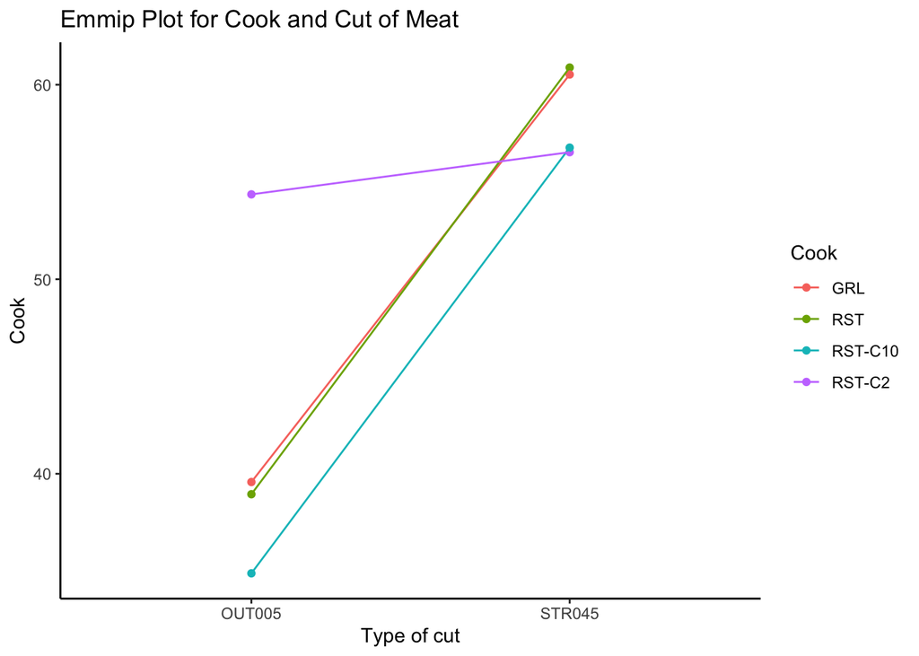

```r
int31 = emmeans(ms, ~ cook + cut)

emmip(int31, cook ~ cut) + theme_classic() + labs(col = "Cook")+ xlab("Type of cut")+ylab("Cook")+ggtitle("Emmip Plot for Cook and Cut of Meat")
```

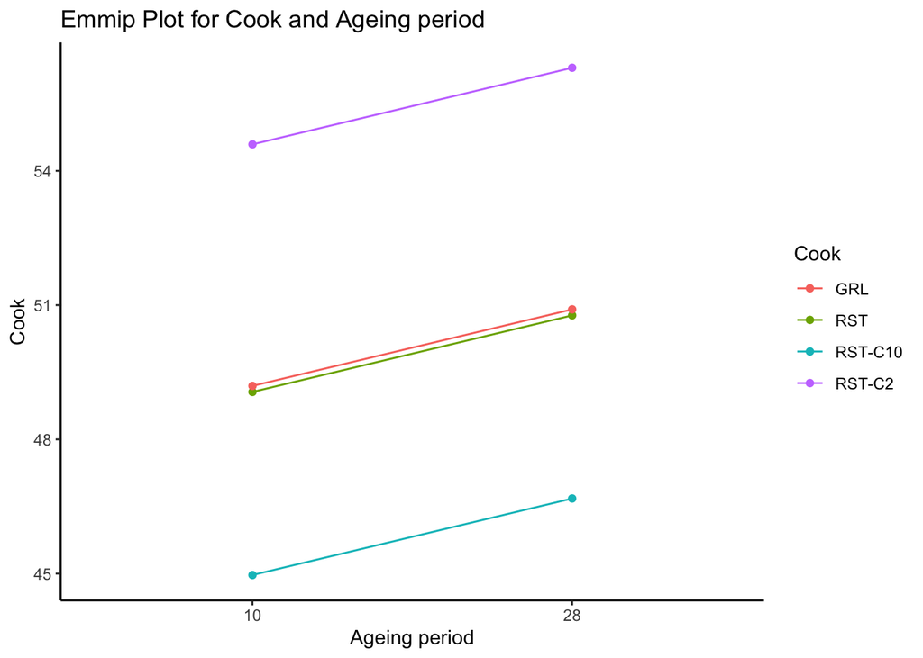

```r
int32 = emmeans(ms, ~ cook + d_aged)

emmip(int32, cook ~ d_aged) + theme_classic() + labs(col = "Cook")+ xlab("Ageing period")+ylab("Cook")+ggtitle("Emmip Plot for Cook and Ageing period")
```

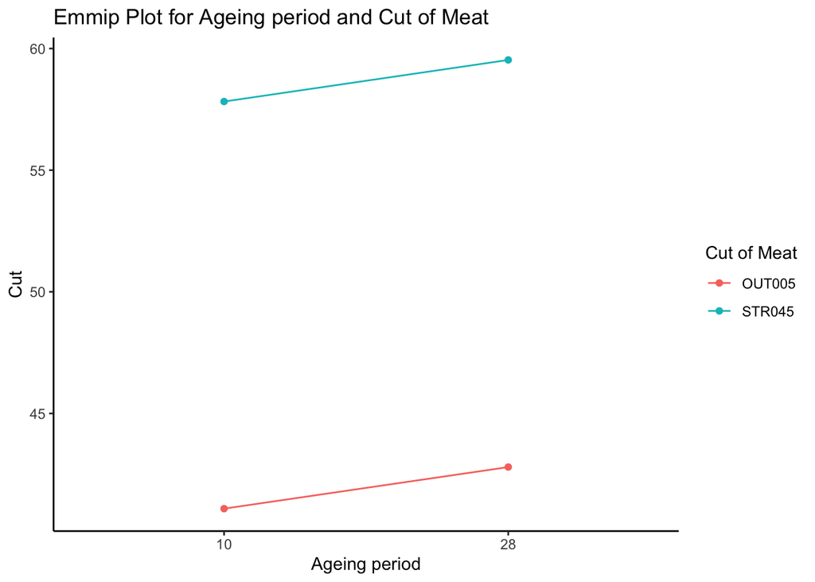

```r
int33 = emmeans(ms, ~ cut + d_aged)

emmip(int33, cut ~ d_aged) + theme_classic() + labs(col = "Cut of Meat")+ xlab("Ageing period")+ylab("Cut")+ggtitle("Emmip Plot for Ageing period and Cut of Meat")
```

We have observed in the interactions plots above that the pair with strong interaction effects is *cook and cut*; and the ones with no interaction effect are: *cut and ageing period* and *cook and ageing period*.

When it comes to the post hoc comparisons, we use *Scheffe’s method* to adjust the p-values becasuse we do not know what pairs we are interested in in the first place.

The question, namely whether the consumers would be able to tell the differences between the meat samples, is more of a subjective one, which is really up to the consumers to give us their judgement. Let’s set the bar to be 5 marks; in cases where the estimated mean difference of the tenderness scores is larger than 5, the difference is significant; if the difference is smaller than 5, then it is not significant. The significance of the differences is an indication of its meaningfulness and whether the consumers would be able to tell the difference between the meat samples.

We will start with the ones with no interaction effect and explore the independent comparisons of the levels of the two factors.

```r
# cut_emm = contrast(emmeans(ms, ~ cut), method = "pairwise", adjust = "scheffe")
# trt_emm = contrast(emmeans(ms, ~ trial_notes), method = "pairwise", adjust = "scheffe")
# dag_emm = contrast(emmeans(ms, ~ d_aged), method = "pairwise", adjust = "scheffe")
# ck_emm = contrast(emmeans(ms, ~ cook), method = "pairwise", adjust = "scheffe")

cut_emm = contrast(emmeans(ms, ~ cut), method = "pairwise", adjust = "scheffe")
trt_emm = contrast(emmeans(ms, ~ trial_notes), method = "pairwise", adjust = "scheffe")
dag_emm = contrast(emmeans(ms, ~ d_aged), method = "pairwise", adjust = "scheffe")
ck_emm = contrast(emmeans(ms, ~ cook), method = "pairwise", adjust = "scheffe")
```

## 3.2 Cut and Ageing Period

```r
ca_emm = update(cut_emm + dag_emm, adjust = "scheffe")
ca_emm
```

```
##  contrast        estimate    SE  df t.ratio p.value
##  OUT005 - STR045   -16.73 1.028 855 -16.280 <.0001
##  10 - 28            -1.71 0.841 855  -2.033 0.1272
##
## Results are averaged over some or all of the levels of: trial_notes, d_aged, cook, cut
```

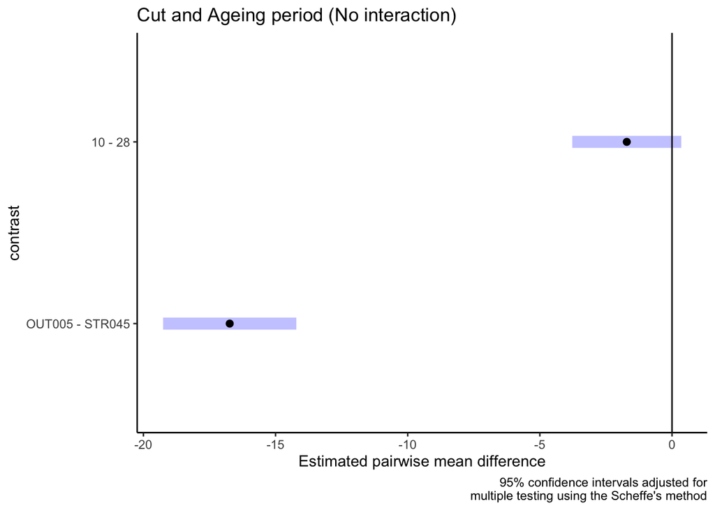

```r
ca_emm %>% plot() + theme_classic() +geom_vline(xintercept = 0) +
  labs(x = "Estimated pairwise mean difference",
       caption = "95% confidence intervals adjusted for\nmultiple testing using the Scheffe's method") +
  ggtitle("Cut and Ageing period (No interaction)")
```

For *cut*, that is the muscle the sample is taken from, the difference between outside flat and striploin is highly significant. The size of the significant difference is quite large with the estimated pairwise mean difference being 16.73. As a result, the difference is quite meaningful and it is very likely that the consumers would be able to tell the difference between outer flat (OUT005) and striploin (STR045).

## 3.3 Cook and Cut

```r
emm1 = emmeans(ms, ~ trial_notes | cook + cut)
contrast(emm1, method = "pairwise", adjust = "scheffe") %>% tidy() %>% filter(p.value <0.05)
```

```
## # A tibble: 8 x 9
##   level1  level2   cook   cut   estimate std.error    df statistic  p.value
##   <chr>   <chr>    <fct>  <fct>    <dbl>     <dbl> <dbl>     <dbl>    <dbl>
## 1 Control Enhanced GRL    OUT0…   -14.6       1.47   855     -9.94 4.14e-22
## 2 Control Enhanced RST    OUT0…   -11.8       1.75   855     -6.72 3.32e-11
## 3 Control Enhanced RST-C… OUT0…    -6.87      2.86   855     -2.40 1.65e- 2
## 4 Control Enhanced RST-C2 OUT0…    -9.40      2.86   855     -3.29 1.04e- 3
## 5 Control Enhanced GRL    STR0…   -19.2       1.49   855    -12.9  4.27e-35
## 6 Control Enhanced RST    STR0…   -16.4       1.75   855     -9.38 5.62e-20
## 7 Control Enhanced RST-C… STR0…   -11.5       2.86   855     -4.02 6.46e- 5
## 8 Control Enhanced RST-C2 STR0…   -14.0       2.86   855     -4.90 1.14e- 6
```

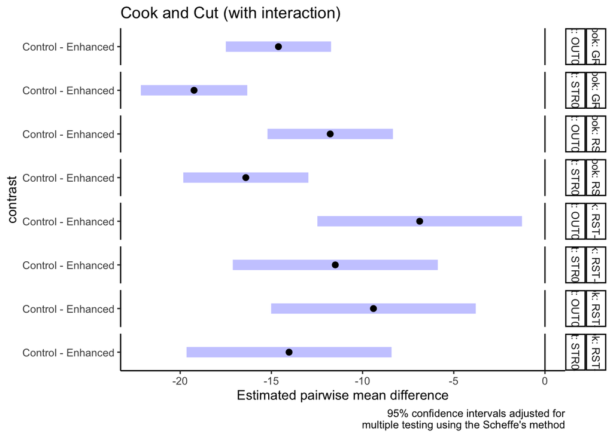

```r
contrast(emm1, method = "pairwise", adjust = "scheffe") %>% plot() + theme_classic() +geom_vline(xintercept = 0) +
  labs(x = "Estimated pairwise mean difference",
       caption = "95% confidence intervals adjusted for\nmultiple testing using the Scheffe's method") +
  ggtitle("Cook and Cut (with interaction)")
```

For the *cook (cooking method) and cut (muscle)* combination, all differences are significant which means that the effect of kiwifruit extract treatment is quite significant especially with the combination of *GRL and STR045* being the most significant (about 12.94) and *RST-C10 and OUT005* being the least signficant (about 6.87) in this instance.

Overall, the majority of these significant differences are quite large, such that the differences are meaningful.

We can conclude that the kiwifruit extract treatment has a significant effect on the meat and it is highly likely that the consumers would be able to tell the differences between the meat being treated with kiwifruit extract and meat which is untreated.

Here the most significant case is where the meat is striploin and is grilled. However, one could argue that there is not much of a disparity between the means of the tenderness scores in the case where the meat is outer flat, roasted, cold and is cut into 10 mm slices since the difference between the tenderness scores has merely scraped the 5-mark bar.

## 3.4 Cook and Ageing Period

```r
coo_emm = update(ck_emm + dag_emm, adjust = "scheffe")
coo_emm
```

```
##  contrast         estimate    SE  df t.ratio p.value
##  GRL - RST           0.134 0.982 855  0.136  1.0000
##  GRL - RST-C10       4.226 1.494 855  2.828  0.0927
##  GRL - RST-C2       -5.398 1.494 855 -3.613  0.0114
##  RST - RST-C10       4.092 1.567 855  2.611  0.1470
##  RST - RST-C2       -5.532 1.567 855 -3.530  0.0147
##  RST-C10 - RST-C2   -9.624 1.932 855 -4.981  0.0001
##  10 - 28            -1.711 0.841 855 -2.033  0.3888
##
## Results are averaged over some or all of the levels of: trial_notes, cut, d_aged, cook
## P value adjustment: scheffe method with dimensionality 4
```

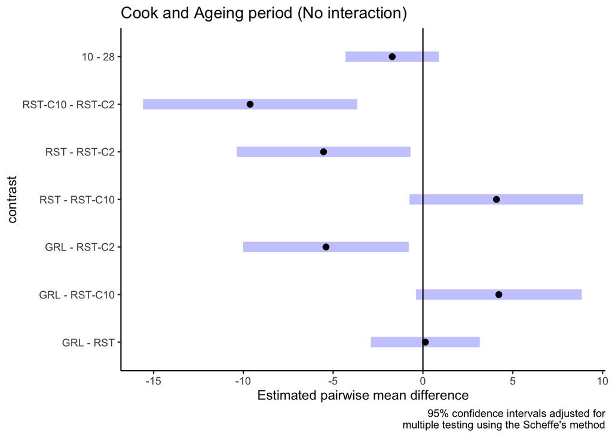

```r
coo_emm %>% plot() + theme_classic() +geom_vline(xintercept = 0) +
  labs(x = "Estimated pairwise mean difference",
       caption = "95% confidence intervals adjusted for\nmultiple testing using the Scheffe's method") +
  ggtitle("Cook and Ageing period (No interaction)")
```

# Conclusion

In conclusion, kiwifruit extract treatment has a significant effect on tenderness in red meat in conjunction with other factors (the muscle the sample is taken from, the ageing period and the cooking method). We have found that there are one combination of the factors which boost the effect of kiwifruit extract treatment on tenderness in red meat quite significantly that is when the meat is striploin and is grilled. Overall, consumers are highly likely to tell the difference between the meat samples. The cooking method alone is also a confounding factor for which the effect of kiwifruit extract is significant; same to the muscle. From this investigation, we can conclude that the kiwifruit extract treatment has an effect on certain combinations of factors (cooking method and muscle) and certain factors alone (muscle and cooking method individually), give you more tender meat, such that the consumers will be able to treat the meat accordingly to enhance their meat eating experience

# Reference

1. Influence Of Kiwifruit Extract Infusion on Consumer Sensory Outcomes Of Striploin (m. Longissimus Lumborum) and Outside Flat (m. Biceps Femoris) from Beef Carcasses Lees- Angela- Tarr- Garth- Polkinghorne- Rod- McGilchrist- Peter - https://www.mdpi.com/2304-8158/8/8/332/htm [Accessed 17 October 2019]
2. Packages below

```r
#Packages we used
#library("ggplot2")
#library("tidyverse")
#library(readxl)
#library(plyr)
#library(ggpubr)
#library(cowplot)
#library(reshape)
#library(ggfortify)
#library(emmeans)
#library(tidyverse)
#library(dplyr)
#library(tibble)
#library(emmeans)
#library(ggfortify)
#library(knitr)
#library(kableExtra)
#library(car)
#library(broom)
```